# R Notebook

Charger les bibliothèques nécessaires

```r
library(dplyr)
library(readr)
library(stringr)
```

```r
print(colnames(donnees))
```

```
 [1] "Species"            "GenomeStatus"       "Strain"             "Segment"            "GenBank Accessions" "Size"
 [7] "GC Content"         "Contig N50"         "CollectionDate"     "CollectionYear"     "IsolationCountry"   "GeographicGroup"
[13] "HostName"           "Host Common Name"   "HostGroup"
```

Étape 1 : Retirer les entrées sans date de collecte ou pays

```r
donnees_filtrees <- donnees %>%
  filter(!is.na(CollectionDate), !is.na(IsolationCountry))
```

Étape 2 : Grouper et résumer le nombre de séquences par pays, année, segment

```r
resume_pays_annee_segment <- donnees_filtrees %>%
  group_by(IsolationCountry, CollectionYear, Segment) %>%
  summarise(Nb_sequences = n(), .groups = "drop")

write_tsv(resume_pays_annee_segment, "resume_pays_annee_segment.tsv")
print(resume_pays_annee_segment)
```

| IsolationCountry | CollectionYear | Segment | Nb_sequences |
| --- | --- | --- | --- |
| Angola | 1985 | M | 1 |
| Angola | 1985 | S | 1 |
| Angola | 2016 | L | 1 |
| Angola | 2016 | M | 1 |
| Angola | 2016 | S | 1 |
| Burkina Faso | 1983 | L | 1 |
| Burkina Faso | 1983 | M | 1 |
| Burkina Faso | 1983 | S | 2 |
| Burundi | 2022 | L | 5 |
| Burundi | 2022 | M | 7 |

[output cut: 236 more lines]

Étape 3 : Créer une colonne dérivée (par exemple : région depuis le pays)

```r
donnees_mutation <- donnees_filtrees %>%
  mutate(Region = case_when(
    IsolationCountry %in% c("Kenya", "Sudan", "Tanzania", "Uganda") ~ "Afrique de l'Est",
    IsolationCountry %in% c("Senegal", "Mauritania") ~ "Afrique de l'Ouest",
    TRUE ~ "Autre"
  ))
```

Etape 4: compter le nombre de sequences par hote commun

```r
compte_hotes <- donnees_mutation %>%
  group_by(`Host Common Name`) %>%
  summarise(Nb_sequences = n(), .groups = "drop") %>%
  arrange(desc(Nb_sequences))

write_tsv(compte_hotes, "compte_hotes.tsv")
print(compte_hotes)
```

| Host Common Name | Nb_sequences |
| --- | --- |
| Human | 769 |
| Cow | 243 |
| Mosquito | 131 |
| NA | 130 |
| Sheep | 70 |
| Goat | 18 |
| Buffalo | 9 |
| Bat | 7 |
| Null | 6 |
| Cattle | 5 |

[output cut: 6 more lines]

Étape 5 : Filtrer par pays, années et segments spécifiques (exemple : Kenya, 2007, segment L)

```r
filtres_specifiques <- donnees_mutation %>%
  filter(IsolationCountry == "Kenya", CollectionYear == 2007, Segment == "L")

print(filtres_specifiques)
```

| Species | GenomeStatus | Strain | Segment | GenBank Accessions | Size | GC Content | Contig N50 | CollectionDate | CollectionYear | IsolationCountry | GeographicGroup | HostName | Host Common Name | HostGroup | Region |
| --- | --- | --- | --- | --- | --- | --- | --- | --- | --- | --- | --- | --- | --- | --- | --- |
| Phlebovirus riftense | Partial | K2 | L | PP746417 | 6386 | 43.84591 | 6386 | 2007-01-01 | 2007 | Kenya | Africa | Homo sapiens | Human | Human | Afrique de l'Est |
| Phlebovirus riftense | Partial | J8 | L | PP746426 | 6251 | 43.57703 | 6251 | 2007-01-01 | 2007 | Kenya | Africa | Homo sapiens | Human | Human | Afrique de l'Est |
| Phlebovirus riftense | Partial | J10 | L | PP746425 | 6232 | 43.54942 | 6232 | 2007-01-01 | 2007 | Kenya | Africa | Homo sapiens | Human | Human | Afrique de l'Est |
| Phlebovirus riftense | Partial | J9 | L | PP746427 | 6277 | 43.53991 | 6277 | 2007-01-11 | 2007 | Kenya | Africa | Homo sapiens | Human | Human | Afrique de l'Est |
| Phlebovirus riftense | Partial | KEM-JC | L | PP746437 | 6268 | 43.51438 | 6268 | 2007-01-01 | 2007 | Kenya | Africa | Homo sapiens | Human | Human | Afrique de l'Est |
| Phlebovirus riftense | Partial | KEM-BR | L | PP746436 | 6232 | 43.51852 | 6232 | 2007-01-03 | 2007 | Kenya | Africa | Homo sapiens | Human | Human | Afrique de l'Est |
| Phlebovirus riftense | Partial | KEM-ND | L | PP746438 | 6232 | 43.40846 | 6232 | 2007-01-01 | 2007 | Kenya | Africa | Homo sapiens | Human | Human | Afrique de l'Est |
| Phlebovirus riftense | Partial | MO-LE | L | PP746448 | 6387 | 43.51025 | 6387 | 2007-01-01 | 2007 | Kenya | Africa | Homo sapiens | Human | Human | Afrique de l'Est |
| Phlebovirus riftense | Partial | HA-HAR | L | PP746447 | 6373 | 43.88828 | 6373 | 2007-01-01 | 2007 | Kenya | Africa | Homo sapiens | Human | Human | Afrique de l'Est |
| Phlebovirus riftense | Partial | MSA | L | PP746449 | 6388 | 43.44083 | 6388 | 2007-01-01 | 2007 | Kenya | Africa | Homo sapiens | Human | Human | Afrique de l'Est |

[output cut: 34 more lines]

Étape 6 : Renommer la colonne CollectionYear en year

```r
donnees_renommee <- donnees_mutation %>%
  rename(year = CollectionYear)
```

Étape 7 : Grouper et résumer par pays, année et segment

```r
resume_final <- donnees_renommee %>%
  group_by(IsolationCountry, year, Segment) %>%
  summarise(Nb_sequences = n(), .groups = "drop")

write_tsv(resume_final, "resume_final.tsv")
print(resume_final)
```

| IsolationCountry | year | Segment | Nb_sequences |
| --- | --- | --- | --- |
| Angola | 1985 | M | 1 |
| Angola | 1985 | S | 1 |
| Angola | 2016 | L | 1 |
| Angola | 2016 | M | 1 |
| Angola | 2016 | S | 1 |
| Burkina Faso | 1983 | L | 1 |
| Burkina Faso | 1983 | M | 1 |
| Burkina Faso | 1983 | S | 2 |
| Burundi | 2022 | L | 5 |
| Burundi | 2022 | M | 7 |

[output cut: 236 more lines]

Étape 8 : Identifier les pays avec le plus grand nombre de séquences complètes (indépendamment du segment)

```r
pays_plus_sequences <- donnees_filtrees %>%
  filter(GenomeStatus == "Complete") %>%
  group_by(IsolationCountry) %>%
  summarise(Nb_sequences_completes = n(), .groups = "drop") %>%
  arrange(desc(Nb_sequences_completes))

write_tsv(pays_plus_sequences, "pays_plus_sequences.tsv")
print(pays_plus_sequences)
```

| IsolationCountry | Nb_sequences_completes |
| --- | --- |
| South Africa | 389 |
| Kenya | 178 |
| Madagascar | 38 |
| Zimbabwe | 35 |
| Central African Republic | 33 |
| Egypt | 33 |
| Uganda | 28 |
| Sudan | 22 |
| Mauritania | 15 |
| Namibia | 12 |

[output cut: 9 more lines]

```r
cat("✅ Analyse terminée. Tous les fichiers résumés ont été sauvegardés dans le répertoire : ", getwd(), "\n")
```

```
✅ Analyse terminée. Tous les fichiers résumés ont été sauvegardés dans le répertoire :  /home/lnsp/Bureau/training_ghana/Travaux_pratique/rvf_africa_projet/resultats
```

Telechargement de librairie

```r
library(dplyr)
library(readr)
```

1️⃣ Nombre d’isolats par pays

```r
isolats_par_pays <- donnees %>%
  group_by(IsolationCountry) %>%
  summarise(Nombre_isolats = n(), .groups = "drop") %>%
  arrange(desc(Nombre_isolats))
print("=== Nombre d'isolats par pays ===")
```

```
[1] "=== Nombre d'isolats par pays ==="
```

```r
print(isolats_par_pays)
```

| IsolationCountry | Nombre_isolats |
| --- | --- |
| South Africa | 434 |
| Kenya | 260 |
| Madagascar | 198 |
| Mauritania | 118 |
| Uganda | 111 |
| Senegal | 52 |
| Egypt | 51 |
| Zimbabwe | 51 |
| Central African Republic | 37 |
| Sudan | 23 |

[output cut: 15 more lines]

```r
NA
```

Sauvegarder le résumé

```r
write_tsv(isolats_par_pays, "nombre_isolats_par_pays.tsv")
```

2️⃣ Nombre d’isolats par an

```r
isolats_par_an <- donnees %>%
  group_by(CollectionYear) %>%
  summarise(Nombre_isolats = n(), .groups = "drop") %>%
  arrange(CollectionYear)
print("=== Nombre d'isolats par an ===")
```

```
[1] "=== Nombre d'isolats par an ==="
```

```r
print(isolats_par_an)
```

| CollectionYear | Nombre_isolats |
| --- | --- |
| 1944 | 10 |
| 1951 | 8 |
| 1955 | 24 |
| 1956 | 4 |
| 1962 | 5 |
| 1963 | 2 |
| 1964 | 1 |
| 1965 | 1 |
| 1969 | 11 |
| 1970 | 5 |

[output cut: 44 more lines]

```r
write_tsv(isolats_par_an, "nombre_isolats_par_an.tsv")
```

3️⃣ Répartition des segments (S, M, L) par pays

```r
repartition_segments <- donnees %>%
  group_by(IsolationCountry, Segment) %>%
  summarise(Nombre = n(), .groups = "drop") %>%
  arrange(IsolationCountry, Segment)

print("=== Répartition des segments par pays ===")
```

```
[1] "=== Répartition des segments par pays ==="
```

```r
print(repartition_segments)
```

| IsolationCountry | Segment | Nombre |
| --- | --- | --- |
| Angola | L | 1 |
| Angola | M | 2 |
| Angola | S | 2 |
| Burkina Faso | L | 1 |
| Burkina Faso | M | 1 |
| Burkina Faso | S | 2 |
| Burundi | L | 5 |
| Burundi | M | 7 |
| Burundi | NA | 5 |
| Central African Republic | L | 11 |

[output cut: 57 more lines]

```r
# Sauvegarder le résumé
write_tsv(repartition_segments, "repartition_segments_par_pays.tsv")

cat("✅ Analyse descriptive terminée. Résultats sauvegardés dans le dossier : ",
    getwd(), "\n")
```

```
✅ Analyse descriptive terminée. Résultats sauvegardés dans le dossier :  /home/lnsp/Bureau/training_ghana/Travaux_pratique/rvf_africa_projet/resultats
```

Assurez-vous que les colonnes sont bien de type approprié

```r
donnees <- donnees %>%
  mutate(CollectionYear = as.integer(CollectionYear),
         CollectionDate = as.Date(CollectionDate, format = "%Y-%m-%d"))
```

Visualisation des données

1️⃣ Boxplot : distribution des dates de collecte par pays

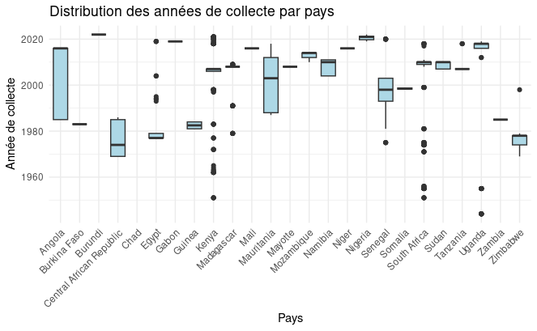

```r
library(ggplot2)

ggplot(donnees, aes(x = IsolationCountry, y = CollectionYear)) +
  geom_boxplot(fill = "lightblue") +
  labs(title = "Distribution des années de collecte par pays",
       x = "Pays",
       y = "Année de collecte") +
  theme_minimal() +
  theme(axis.text.x = element_text(angle = 45, hjust = 1))

ggsave("boxplot_annee_par_pays.png", width = 8, height = 5)
```

2️⃣ Boxplot : distribution des années de collecte par segment

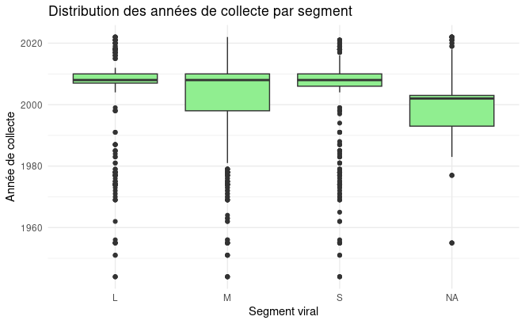

```r
ggplot(donnees, aes(x = Segment, y = CollectionYear)) +
  geom_boxplot(fill = "lightgreen") +
  labs(title = "Distribution des années de collecte par segment",
       x = "Segment viral",
       y = "Année de collecte") +
  theme_minimal()

ggsave("boxplot_annee_par_segment.png", width = 6, height = 5)
```

3️⃣ Résumé : nombre d’isolats par pays et année

```r
resume_pays_annee <- donnees %>%
  group_by(IsolationCountry, CollectionYear) %>%
  summarise(Nb_isolats = n(), .groups = "drop") %>%
  arrange(desc(Nb_isolats))

print("Résumé des isolats par pays et année :")
```

```
[1] "Résumé des isolats par pays et année :"
```

```r
print(resume_pays_annee)
```

| IsolationCountry | CollectionYear | Nb_isolats |
| --- | --- | --- |
| South Africa | 2010 | 279 |
| Madagascar | 2008 | 171 |
| Kenya | 2007 | 152 |
| Uganda | 2018 | 49 |
| South Africa | 2008 | 35 |
| Kenya | 2006 | 27 |
| Mauritania | 1987 | 27 |
| South Africa | 2011 | 27 |
| Zimbabwe | 1978 | 27 |
| South Africa | 2009 | 26 |

[output cut: 103 more lines]

```r
write_tsv(resume_pays_annee, "resume_isolats_par_pays_annee.tsv")
```

4️⃣ Barplot : distribution des souches par pays

[figure not shown]

```r
ggplot(donnees, aes(x = IsolationCountry, fill = Strain)) +
  geom_bar(position = "dodge") +
  labs(title = "Distribution des souches par pays",
       x = "Pays",
       y = "Nombre d’isolats",
       fill = "Souche (Strain)") +
  theme_minimal() +
  theme(axis.text.x = element_text(angle = 45, hjust = 1))

ggsave("barplot_souches_par_pays.png", width = 8, height = 5)
```

```r
cat("✅ Graphiques générés et sauvegardés dans : ", getwd(), "\n")
```

```
✅ Graphiques générés et sauvegardés dans :  /home/lnsp/Bureau/training_ghana/Travaux_pratique/rvf_africa_projet/resultats
```